# Segmentação de clientes de um supermercado

# 1.Introdução

**Este é o meu primeiro projeto end-to-end, por isso, é o mais simples do meu portifólio.** Foi utilizado dados de um supermercado. Estes dados estão disponíveis no [Kaggle](https://www.kaggle.com/code/hunter0007/predictive-marketing-k-means-clustering-pca) .

O objetivo é segmentar os clientes de acordo com o perfil de compras usando o algoritmo Kmeans e o método do cotovelo.

Espera-se, no final, descobrir um pouco mais sobre o perfil dos clientes e padrões de compras. Isto é útil, por exemplo, para criar campanhas de marketing.

# 2. Tecnologias

Foi utilizado a linguagem R, o Excel e o Power BI

# 3. Coleta dos dados

Carregar os pacotes

```r
library(gmodels)
library(dplyr)
library(data.table)
library(tidyr)
library(ggplot2)
library(tidyverse)
library(factoextra)
library(scales) #escala nos gráficos
library(corrplot)#Gráfico de correlação
library(vcd)
library(cluster)
```

Carregar a base de dados

```r
dados <- read.csv("C:/0.Projetos/1.Projeto-Supermercado/Dataset/Supermarket_dataset_for_predictive_marketing_2023.csv")
```

```r
head(dados)
```

```
##   order_id user_id order_number order_dow order_hour_of_day
## 1  2425083   49125            1         2                18
## 2  2425083   49125            1         2                18
## 3  2425083   49125            1         2                18
## 4  2425083   49125            1         2                18
## 5  2425083   49125            1         2                18
## 6  2425083   49125            1         2                18
##   days_since_prior_order product_id add_to_cart_order reordered department_id
## 1                     NA         17                 1         0            13
## 2                     NA         91                 2         0            16
## 3                     NA         36                 3         0            16
## 4                     NA         83                 4         0             4
## 5                     NA         83                 5         0             4
## 6                     NA         91                 6         0            16
##   department       product_name
## 1     pantry baking ingredients
## 2 dairy eggs    soy lactosefree
## 3 dairy eggs             butter
## 4    produce   fresh vegetables
## 5    produce   fresh vegetables
## 6 dairy eggs    soy lactosefree
```

# 4. Conhecer os dados

```r
#Numero de linhas e colunas
n_linhas <- nrow(dados)

n_colunas <- ncol(dados)

cat("O conjunto de dados tem", n_linhas, "linhas e", n_colunas, "colunas.")
```

```
## O conjunto de dados tem 2019501 linhas e 12 colunas.
```

```r
#Verificando o formato das colunas
sapply(dados, class)
```

```
##               order_id                user_id           order_number
##              "integer"              "integer"              "integer"
##              order_dow      order_hour_of_day days_since_prior_order
##              "integer"              "integer"              "numeric"
##             product_id      add_to_cart_order              reordered
##              "integer"              "integer"              "integer"
##          department_id             department           product_name
##              "integer"            "character"            "character"
```

# 5.Limpeza dos dados

```r
#Dados Nulos
porcentagem_nulos <- colSums(is.na(dados))/nrow(dados)*100
porcentagem_nulos
```

```
##               order_id                user_id           order_number
##               0.000000               0.000000               0.000000
##              order_dow      order_hour_of_day days_since_prior_order
##               0.000000               0.000000               6.157066
##             product_id      add_to_cart_order              reordered
##               0.000000               0.000000               0.000000
##          department_id             department           product_name
##               0.000000               0.000000               0.000000
```

```r
summary(dados$days_since_prior_order)
```

```
##    Min. 1st Qu.  Median    Mean 3rd Qu.    Max.    NA's
##    0.00    5.00    8.00   11.39   15.00   30.00  124342
```

Retirada das NA´s Será feito isso, pois as NA´s correspondem a clientes que não compraram no período de 30 dias ou clientes novos.

```r
#Eliminamos as NA
#Cria-se uma nova base de dados elimando as NA´s
dados2 <- dados[!is.na(dados$days_since_prior_order), ]
```

```r
summary(dados2$days_since_prior_order)
```

```
##    Min. 1st Qu.  Median    Mean 3rd Qu.    Max.
##    0.00    5.00    8.00   11.39   15.00   30.00
```

```r
class(dados2$days_since_prior_order)
```

```
## [1] "numeric"
```

SOBRE A VARIAVEL “days_since_prior_order” 1. Observa-se que o número maximo de dias desde a última compra é 30, logo, pode-se supor que essa contagem é mensal. 2. O minimo de dias é 0, isso pode indicar novos clientes. 25% tem uma variação de 5 dias entres as compras. 3. A mediana é 8, isso significa que metade dos clientes tem 8 dias de diferenças entre as compras. 4. As NA´s podem indicar clientes que não fazem compras a mais de 1 mês.

```r
#Saber quantos user id tem na base de dados
#unique: vai considerar os unicos dados
user_id_unicos <- unique(dados$user_id)
#lenght:quantos tem na lista de unique
n_user_id_unicos <- length(user_id_unicos)

cat("O conjunto de dados tem", n_user_id_unicos, "clientes")
```

```
## O conjunto de dados tem 105273 clientes
```

# 6. Transformação dos dados

Será feito agrupamento dos clientes para encontrar o histórico de compra de cada um.

```r
#Agrupamento de clientes (desconsiderando os novos clientes)
dados2_grouped <- dados2 %>%
  group_by(user_id) %>%
  summarise(max_dias_desde_a_ultima_compra = max(days_since_prior_order))

head(dados2_grouped)
```

```
## # A tibble: 6 × 2
##   user_id max_dias_desde_a_ultima_compra
##     <int>                          <dbl>
## 1       2                             10
## 2       3                             20
## 3       7                             30
## 4      10                             14
## 5      11                             30
## 6      13                              7
```

Os departamentos estão inseridos como linha, por isso, será feita suas transposição para que eles sejam considerados colunas e utilizados no clustering.

```r
#Transposta do departamento
dados2_spread <- dados2 %>%
  group_by(user_id, department) %>%
  summarise(count = n()) %>%
  spread(department, count, fill = 0)

head(dados2_spread)
```

```
## # A tibble: 6 × 22
## # Groups:   user_id [6]
##   user_id alcohol babies bakery beverages breakfast  bulk `canned goods`
##     <int>   <dbl>  <dbl>  <dbl>     <dbl>     <dbl> <dbl>          <dbl>
## 1       2       0      0      0         0         0     0              0
## 2       3       0      0      0         1         0     0              0
## 3       7       0      0      1         7         0     0              2
## 4      10       0      0      0         0         0     0              0
## 5      11       0      0      0         3         0     0              0
## 6      13       0      0      2         0         0     0              1
## # ℹ 14 more variables: `dairy eggs` <dbl>, deli <dbl>, `dry goods pasta` <dbl>,
## #   frozen <dbl>, household <dbl>, international <dbl>, `meat seafood` <dbl>,
## #   missing <dbl>, other <dbl>, pantry <dbl>, `personal care` <dbl>,
## #   pets <dbl>, produce <dbl>, snacks <dbl>
```

```r
#Unir as tabelas  dados2_grouped e dados2_spread
#Será usada para modelagem
final_df <- left_join(dados2_grouped, dados2_spread, by = "user_id")
head(final_df)
```

```
## # A tibble: 6 × 23
##   user_id max_dias_desde_a_ult…¹ alcohol babies bakery beverages breakfast  bulk
##     <int>                  <dbl>   <dbl>  <dbl>  <dbl>     <dbl>     <dbl> <dbl>
## 1       2                     10       0      0      0         0         0     0
## 2       3                     20       0      0      0         1         0     0
## 3       7                     30       0      0      1         7         0     0
## 4      10                     14       0      0      0         0         0     0
## 5      11                     30       0      0      0         3         0     0
## 6      13                      7       0      0      2         0         0     0
## # ℹ abbreviated name: ¹max_dias_desde_a_ultima_compra
## # ℹ 15 more variables: `canned goods` <dbl>, `dairy eggs` <dbl>, deli <dbl>,
## #   `dry goods pasta` <dbl>, frozen <dbl>, household <dbl>,
## #   international <dbl>, `meat seafood` <dbl>, missing <dbl>, other <dbl>,
## #   pantry <dbl>, `personal care` <dbl>, pets <dbl>, produce <dbl>,
## #   snacks <dbl>
```

# 7. Análise Descritiva

## 7.1 Frequência de compra dos clientes

O objetivo é responder a seguinte pergunta: Quantas vezes por mês um cliente costuma ir ao mercado?

```r
#Criar uma tabela de frequencia
freq_compra <- table(final_df$max_dias_desde_a_ultima_compra)
freq_compra
```

```
##
##     0     1     2     3     4     5     6     7     8     9    10    11    12
##   815  1268  2003  2789  3680  4191  5515  8629  5901  4040  3585  3205  3057
##    13    14    15    16    17    18    19    20    21    22    23    24    25
##  3356  4187  2959  2031  1780  1713  1564  1730  2168  1582  1129  1032   972
##    26    27    28    29    30
##   921  1084  1313  1001 19718
```

```r
# Converter a tabela de frequência em um dataframe
freq_compra1 <- as.data.frame(freq_compra)
freq_compra1
```

```
##    Var1  Freq
## 1     0   815
## 2     1  1268
## 3     2  2003
## 4     3  2789
## 5     4  3680
## 6     5  4191
## 7     6  5515
## 8     7  8629
## 9     8  5901
## 10    9  4040
## 11   10  3585
## 12   11  3205
## 13   12  3057
## 14   13  3356
```

[output cut: 17 more lines]

```r
#Nomear as colunas
names(freq_compra1) <- c("Quantidade_de_dias_entre_as_compras", "Frequencia")
names(freq_compra1)
```

```
## [1] "Quantidade_de_dias_entre_as_compras" "Frequencia"
```

```r
# Ordenar o dataframe em ordem decrescente
freq_compra_ordenada <- freq_compra1 %>% arrange(desc(Frequencia)) %>% mutate(
  Porcentagem_da_freq = (Frequencia/ sum(Frequencia)*100)
)
freq_compra_ordenada
```

```
##    Quantidade_de_dias_entre_as_compras Frequencia Porcentagem_da_freq
## 1                                   30      19718          19.9336824
## 2                                    7       8629           8.7233870
## 3                                    8       5901           5.9655472
## 4                                    6       5515           5.5753250
## 5                                    5       4191           4.2368426
## 6                                   14       4187           4.2327989
## 7                                    9       4040           4.0841909
## 8                                    4       3680           3.7202531
## 9                                   10       3585           3.6242140
## 10                                  13       3356           3.3927091
## 11                                  11       3205           3.2400574
## 12                                  12       3057           3.0904385
## 13                                  15       2959           2.9913666
## 14                                   3       2789           2.8195071
```

[output cut: 17 more lines]

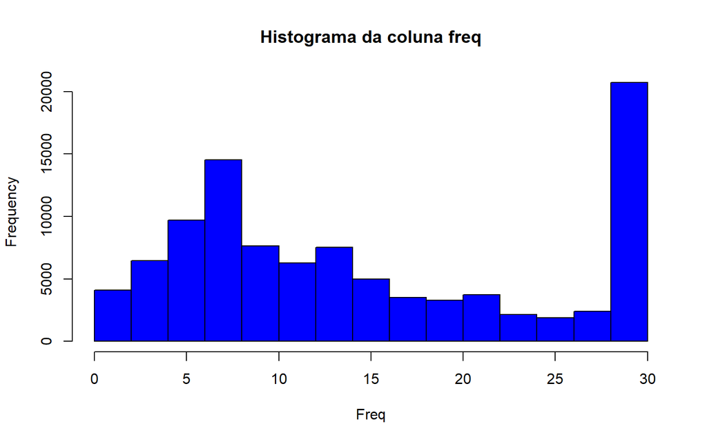

```r
#Gráfico da Frequência de compras
hist(final_df$max_dias_desde_a_ultima_compra, main = "Histograma da coluna freq", xlab = "Freq", col = "blue")
```

```r
#Alguns clientes compram a cada 7 dias e outros que compram a cada 30 dias
```

## 7.2 Moda por cliente: Qual dia os clientes costumam ir mais vezes ao supermercado?

Esta pergunta é importante, pois, ajudaria o supermercado a alocar mais funcionários para estes dias.

```r
#Tabela de frequencia
tabela_frequencia <- table(dados$order_dow)
tabela_frequencia
```

```
##
##      0      1      2      3      4      5      6
## 391831 349236 261912 238730 234884 262157 280751
```

```r
# Encontra a moda
moda <- as.numeric(names(tabela_frequencia[tabela_frequencia == max(tabela_frequencia)]))
print(moda)
```

```
## [1] 0
```

```r
cat("O dia que os clientes mais costumam comprar é no domingo")
```

```
## O dia que os clientes mais costumam comprar é no domingo
```

```r
#Gráfico
#1.Converter os dados em data.frame
tabela_grafico <- as.data.frame(tabela_frequencia)
names(tabela_grafico) <- c("Dia_da_compra", "Frequencia")
str(tabela_grafico)
```

```
## 'data.frame':    7 obs. of  2 variables:
##  $ Dia_da_compra: Factor w/ 7 levels "0","1","2","3",..: 1 2 3 4 5 6 7
##  $ Frequencia   : int  391831 349236 261912 238730 234884 262157 280751
```

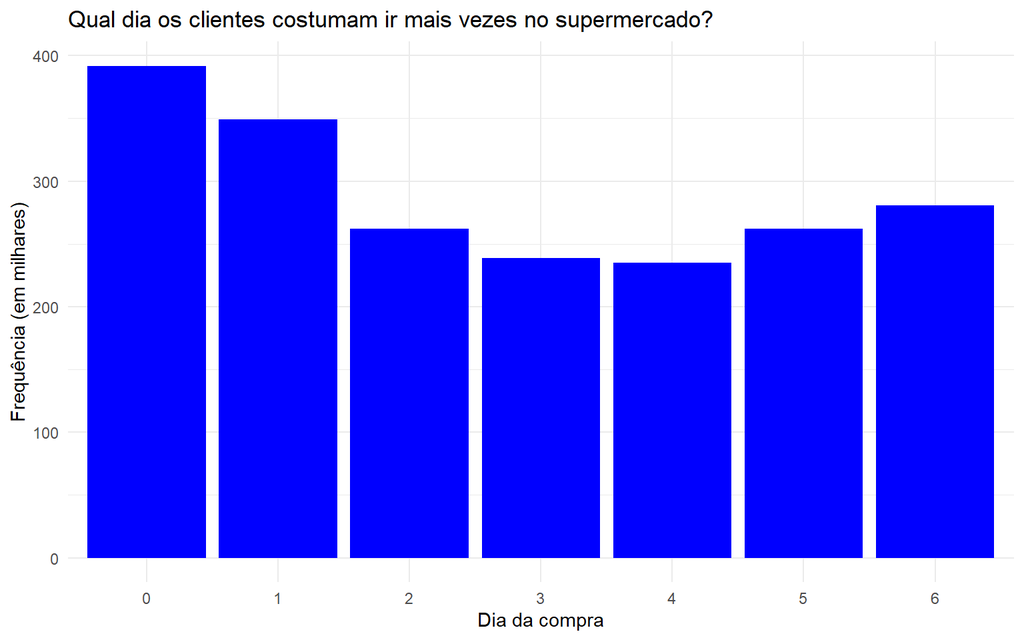

```r
#2.Criar o gráfico
ggplot(tabela_grafico, aes(x = Dia_da_compra, y = Frequencia))+
  geom_bar(stat = "identity", fill = "blue")+
  ggtitle("Qual dia os clientes costumam ir mais vezes no supermercado?") +
  xlab("Dia da compra") +
  ylab("Frequência (em milhares)")+
  scale_y_continuous(labels = label_number(scale = 1e-3))+theme_minimal()
```

## 7.3 Departamentos que vendem mais itens

Apesar do dataset não ter o valor dos produtos, saber quais departamentos vendem mais pode ser um indicativo de onde vem a maior parte do lucro do supermercado.

```r
#Tabela que agrupa por departamento e conta os itens que cada cliente compra
df_grupo <- dados2 %>%
  group_by(user_id, department) %>%
  summarise(count = n())
df_grupo
```

```
## # A tibble: 599,586 × 3
## # Groups:   user_id [98,918]
##    user_id department count
##      <int> <chr>      <int>
##  1       2 dairy eggs     2
##  2       2 deli           3
##  3       2 produce        3
##  4       2 snacks         3
##  5       3 beverages      1
##  6       3 dairy eggs     5
##  7       3 frozen         2
##  8       3 household      1
##  9       3 pantry         1
## 10       3 produce        6
## # ℹ 599,576 more rows
```

```r
#Tabela que soma os itens vendidos de cada departamento
df_sum <- df_grupo %>%
  group_by(department) %>%
  summarise(sum_count = sum(count))
df_sum
```

```
## # A tibble: 21 × 2
##    department      sum_count
##    <chr>               <int>
##  1 alcohol              8663
##  2 babies              24633
##  3 bakery              68430
##  4 beverages          158100
##  5 breakfast           41733
##  6 bulk                 2036
##  7 canned goods        61844
##  8 dairy eggs         316966
##  9 deli                60934
## 10 dry goods pasta     50475
## # ℹ 11 more rows
```

```r
#Tabela que o ranking dos 10 melhores departametos
df_top10 <- df_sum %>%
  arrange(desc(sum_count)) %>%
  head(10)

cat("Observa-se que os departametos que mais vende são respectivamente:produce, dairy eggs, snacks")
```

```
## Observa-se que os departametos que mais vende são respectivamente:produce, dairy eggs, snacks
```

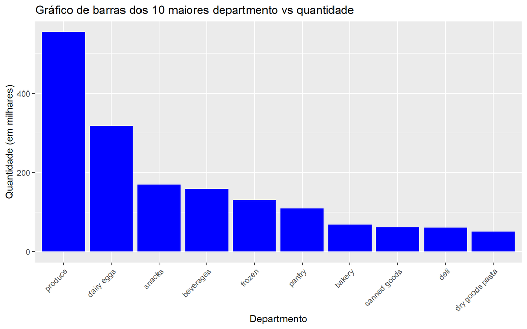

```r
#Gráfico com a quantidade vendida pelos 10 maiores departamentos
ggplot(df_top10, aes(x = reorder(department, -sum_count), y = sum_count)) +
  geom_bar(stat = "identity", fill = "blue") +
  ggtitle("Gráfico de barras dos 10 maiores departmento vs quantidade") +
  xlab("Departmento") +
  ylab("Quantidade (em milhares)") +
  theme(axis.text.x = element_text(angle = 45, hjust = 1))+
  scale_y_continuous(labels = label_number(scale = 1e-3))
```

## 7.4 Horários de maior venda

Os horários de maior venda são entre as 8h e às 17h. É ideal que nestes horários o supermercado coloque mais funcionários no Caixa, por exemplo.

```r
tempo <- dados2 %>% group_by(order_hour_of_day) %>%
  summarise(total_produtos_vendidos=sum(add_to_cart_order))

tempo1 <- tempo %>% arrange(desc(total_produtos_vendidos))
head(tempo1, 10)
```

```
## # A tibble: 10 × 2
##    order_hour_of_day total_produtos_vendidos
##                <int>                   <int>
##  1                10                 1384044
##  2                11                 1362320
##  3                13                 1328803
##  4                14                 1306307
##  5                12                 1297292
##  6                15                 1293392
##  7                16                 1208369
##  8                 9                 1205173
##  9                17                  968255
## 10                 8                  867536
```

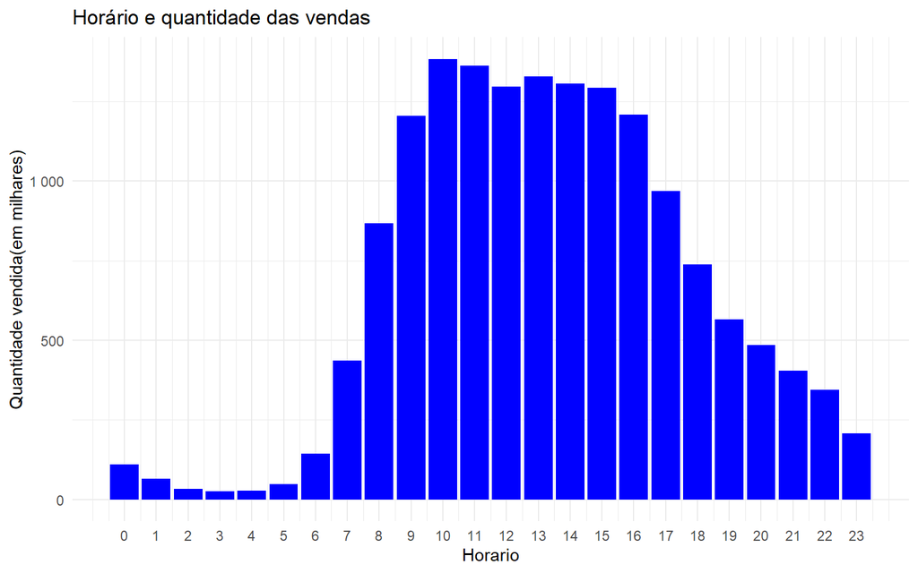

```r
ggplot(tempo1, aes(x = order_hour_of_day, y = total_produtos_vendidos))+
  geom_bar(stat = "identity", fill = "blue")+
  ggtitle("Horário e quantidade das vendas") +
  xlab("Horario") +
  ylab("Quantidade vendida(em milhares)")+
  scale_y_continuous(labels = label_number(scale = 1e-3))+
  scale_x_continuous(breaks = seq(0, 23, by= 1))+theme_minimal()
```

## 7.5 Ranking dos produtos mais vendidos do supermercado

Saber quais os alimentos mais vendidos é importante para o supermercado se descobrir quais alimentos ele deve repor com mais frequência.

```r
#Tabela que agrupa por produto e conta os itens que cada cliente compra
top_produtos1 <-  dados2 %>%
  group_by(user_id, product_name) %>%
  summarise(count = n())
#Tabela que soma os produtos vendidos
top_produtos2 <- top_produtos1 %>%
  group_by(product_name) %>%
  summarise(total = sum(count))

#Tabela que com o ranking dos 10 produtos mais vendidos
top_produtos3<- top_produtos2 %>%
  arrange(desc(total)) %>%
  head(10)

top_produtos3
```

```
## # A tibble: 10 × 2
##    product_name                   total
##    <chr>                          <int>
##  1 fresh fruits                  213224
##  2 fresh vegetables              199526
##  3 packaged vegetables fruits    103016
##  4 yogurt                         85176
##  5 packaged cheese                57683
##  6 milk                           52154
##  7 water seltzer sparkling water  49679
##  8 chips pretzels                 42498
##  9 soy lactosefree                37098
## 10 bread                          34123
```

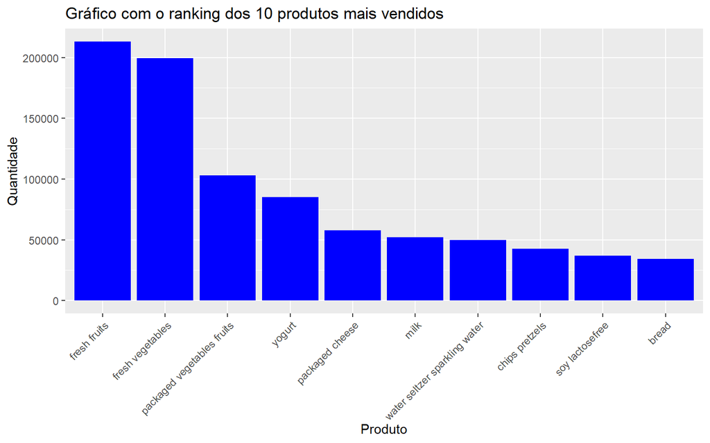

```r
#Gráfico com o ranking dos 10 produtos mais vendidos
#OBS: reorder() organiza "product_name" com base nos valores de "total" em ordem decrescente
grafico_produtos <- ggplot(top_produtos3, aes(x = reorder(product_name, -total), y = total)) +
  geom_bar(stat = "identity", fill = "blue") +
  ggtitle("Gráfico com o ranking dos 10 produtos mais vendidos") +
  xlab("Produto") +
  ylab("Quantidade") +
  theme(axis.text.x = element_text(angle = 45, hjust = 1))

print(grafico_produtos)
```

```r
#produto mais vendido é fresh fruits, seguido de fresh vegetables.
```

# 8. Modelagem

Nesta parte, será utilizado o algoritmo Kmeans para fazer a clusterização.

## 8.2 Amostragem aleatória

Como a base de dados é muito grande, será utilizado uma amostra aleatória para realizar o clustering

```r
#Definir o tamanho da amostra
sample_size <- 10000

#Amostragem aleatoria
sampled_dataset <- final_df[sample(nrow(final_df), sample_size), ]
```

## 8.3 Segmentação teste Kmeans pelo metodo do cotovelo

Este método tem o intuito de mapear o número de cluster a ser utilizado

```r
#Tirar a coluna user_id
df_numeric <- select_if(sampled_dataset, is.numeric) %>%
  select(-user_id)
```

```r
#Semente aleatoria
set.seed(123)
#Faz uma segmentação de 1 até 10 clusters
wss <- map_dbl(1:10, function(k) {
  kmeans(df_numeric, centers = k, nstart = 10)$tot.withinss
})

#nstart = 10 numero de interações
```

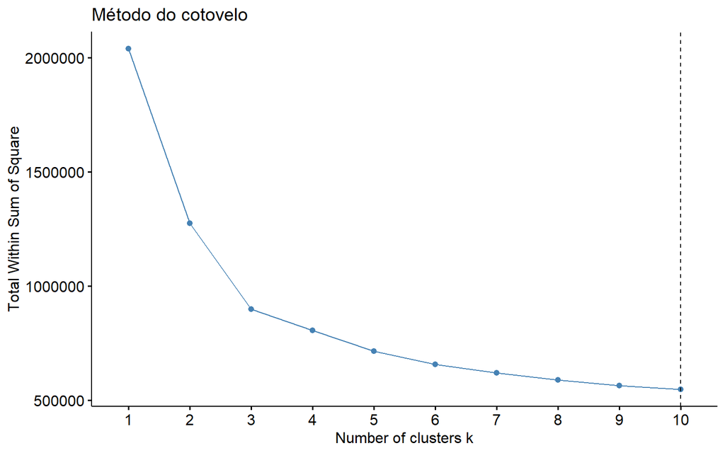

```r
#Metodo do cotovelo
fviz_nbclust(df_numeric, kmeans, method = "wss") +
  geom_vline(xintercept = which.min(wss), linetype = 2) +
  ggtitle("Método do cotovelo")
```

## 8.4 Padronização

Essa padronização tem como objetivo colocar todas as colunas na mesma escala para em seguida realizar o clustering

```r
media_original <- colMeans(df_numeric, na.rm = TRUE)
desvio_padrao_original <- apply(df_numeric, 2, sd, na.rm = TRUE)
#Escalei os numeros da amostra (padronização)
df_scaled <- scale(df_numeric)
#OBS: df_scale resultou numa matriz
```

## 8.5 Clustering

```r
km_result <- kmeans(df_scaled, centers = 5)
#OBS: km_result originou uma lista
```

## 8.6 dados padronizados à valores originais

```r
#Estou voltando com os dados originais
df_original <- scale(df_scaled, center = -media_original/desvio_padrao_original, scale = 1/desvio_padrao_original)
#OBS: df_original resultou numa matriz.
#     Logo, para uni-la a uma "km_result" (lista),
#     eu precisarei converter os dados para data.frame.

#Converter df_original de "matrix" para "data.frame"
df_original <- data.frame(df_original)

#Unir "df_original" com "km_result$cluster"
#Adicionar uma coluna chamada cluster que é o resultado da segmentação anterior
df_original$cluster <- km_result$cluster

#Salvar a base de dados
df_original %>% write.csv("df_original.csv")
```

**Os próximos passos :** gerar uma tabela com os resumos dos dados no Excel e criar um dashboard no Power BI.